# Tutorial of InstaPrism

Mengying Hu

2024-06-03

## Introduction

**InstaPrism** is an R package for cell type composition and gene expression deconvolution in bulk RNA-Seq data.

Based on the same conceptual Bayesian framework as BayesPrism, InstaPrism re-implements BayesPrism in a derandomized framework by replacing the time-consuming Gibbs sampling steps in BayesPrism with a fixed-point algorithm, which greatly accelerated the calculation speed while maintaining highly comparable performance. It works as an independent R package and does not require the users to have BayesPrism installed.

This tutorial is associated the latest version of InstaPrism (InstaPrism v0.1.6). `extdata` folder associated with this tutorial can be downloaded from [zenodo](https://zenodo.org/record/7730658) repository.

## Quick start with your own data

Load the **InstaPrism** package.

```r
library(InstaPrism)
```

#### 1. Prepare the bulk input

Here we provide an example of TPM-normalized bulk expression data from ovarian cancer. For deconvolution with InstaPrism, the bulk input should be in a non-log transformed scale (TPM or count).

```r
bulk_expr = read.csv(system.file('extdata','example_bulk.csv',package = 'InstaPrism'))
bulk_expr[1:5,1:5]
```

```
#>            simulated1 simulated2  simulated3 simulated4 simulated5
#> AL627309.1   4.083809   2.506129  0.13908015 11.0578698   3.548361
#> LINC00115    1.339467   3.788035  0.04873877  0.4734699   1.364752
#> SAMD11       1.310678   2.586227  0.00000000  0.6388871   1.059823
#> NOC2L       51.436820  64.370597 48.12664982 25.8605285  46.726963
#> HES4        18.179669  17.233774 20.57675914 13.4103796   6.820316
```

#### 2. Prepare the reference

A reference profile containing prior knowledge from the same tissue type is required for InstaPrism deconvolution. With the provided ovarian cancer bulk example, we can utilize the built-in ovarian cancer reference.

```r
OV_ref = InstaPrism_reference('OV')
```

This reference contains two layers of information: 1) a probability matrix **phi.cs** that specifies the event probability of a gene being expressed in a cell state; and 2) a **map** list that specifies the corresponding cell type for each cell state.

#### 3. Deconvolution with InstaPrism

Upon preparation of the necessary inputs, the deconvolution task can be accomplished with the `InstaPrism()` function:

```r
deconv_res = InstaPrism(bulk_Expr = bulk_expr, refPhi_cs = OV_ref)
```

#### 4. Obtain deconvolution results

InstaPrism provides both cell type fraction and gene expression deconvolution. The deconvolved cell type fraction is accessible with:

```r
estimated_frac = t(deconv_res@Post.ini.ct@theta)
head(estimated_frac)
```

```
#>             malignant   fibroblast      T cell endothelial cell  plasma cell
#> simulated1 0.24599682 0.1043896646 0.085552934     4.579146e-04 2.803916e-03
#> simulated2 0.47190324 0.0446163982 0.160564964     1.005954e-03 9.584606e-03
#> simulated3 0.16201096 0.0005638522 0.022601652     1.203416e-04 3.604128e-01
#> simulated4 0.15632095 0.0072655750 0.001040862     2.443712e-06 1.101534e-02
#> simulated5 0.09125095 0.0993022141 0.031802375     3.882045e-04 1.902238e-01
#> simulated6 0.42893249 0.2377917946 0.002802920     5.242899e-05 3.291944e-05
#>                  B cell dendritic cell    mast cell  monocyte
#> simulated1 5.718360e-06   8.119027e-02 1.979231e-04 0.4794048
#> simulated2 1.233473e-07   7.094381e-03 3.193487e-04 0.3049110
#> simulated3 3.907032e-06   5.349831e-04 7.677726e-06 0.4537438
#> simulated4 6.431559e-10   1.287934e-03 6.537324e-07 0.8230662
#> simulated5 1.866926e-06   1.088380e-01 1.243421e-04 0.4780682
#> simulated6 8.267316e-10   1.204444e-05 1.080902e-05 0.3303646
```

The cell types in the deconvolved cell type fraction table correspond to the cell types provided in the reference. In other words, given the reference, InstaPrism will return posterior estimates for the cell types in the reference.

The cell-type specific gene expression deconvolution results can be obtained by

```r
Z = get_Z_array(deconv_res)
```

This Z array is a sample by gene by cell-type array

```r
dim(Z)
```

```
#> [1]    50 10682     9
```

To extract a cell-type specific gene expression, one can use

```r
mal_Z = Z[,,'malignant']
head(mal_Z[,1:5])
```

```
#>            AL627309.1   LINC00115    SAMD11     NOC2L      HES4
#> simulated1 0.93815744 0.288139710 0.9696119 20.181195  7.499987
#> simulated2 1.20042099 1.637395361 2.3868686 40.434788 12.456036
#> simulated3 0.02046599 0.006864074 0.0000000 11.534905  9.177751
#> simulated4 1.50700887 0.059112127 0.5576810  8.360676  5.988685
#> simulated5 0.27981013 0.117333532 0.4730975  7.121446  1.292857
#> simulated6 1.93678298 0.800371705 2.9196245 30.616721 17.255400
```

Or directly use `reconstruct_Z_ct_initial()` function to get a specific gene expression of interest

```r
mal_Z = reconstruct_Z_ct_initial(InstaPrism_obj = deconv_res, cell.type.of.interest = 'malignant')
```

#### 5. Examine deconvolution performance

We provide a useful `deconv_performance_plot()` function to visualize the correlation between the estimated and ground truth cell type fractions. Since the names of the estimated and ground truth cell types may not always match, the function incorporates an automatic matching step. Specifically, for each cell type in the ground truth, the function identifies the most strongly correlated cell type in the estimated fractions, and labeled it as `maxCorName` in the visualization.

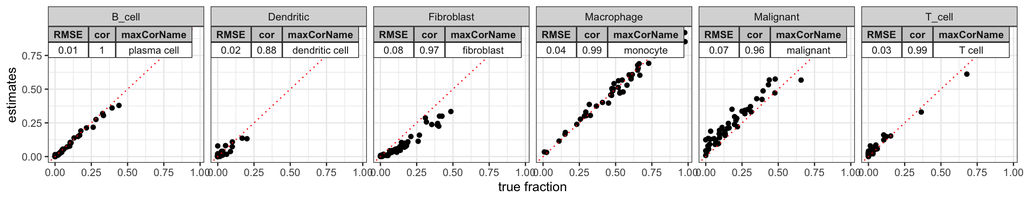

```r
# load ground truth cell type fractions for the example bulk data
truth_frac = read.csv(system.file('extdata','truth_frac.csv',package = 'InstaPrism'))
deconv_performance_plot(truth_frac = truth_frac,estimated_frac = t(deconv_res@Post.ini.ct@theta))
```

## De novo reference construction

In the previous example we demonstrated a deconvolution process using the InstaPrism built-in reference. In real practice, users can generate their own reference profiles using the `refPrepare()` function, which takes the following inputs:

- **scExpr**: a single-cell expression data as prior information (raw count or CPM normalized expression)
- **cell.type.labels**: a character vector indicating cell types of each cell from the scRNA data
- **cell.state.labels**: a character vector indicating cell states of each cell from the scRNA data

Cell type labels indicate the broad classification of cells based on their biological or functional identity, such as T cells, B cells, or malignant cells; whereas cell state labels indicate more specific statuses within each cell type, which can be derived from subclustering information from each cell type. Accounting for cell state specifications is crucial for addressing the heterogeneity within a cell type, thereby enhancing the robustness of deconvolution results.

Below, we provide an example showing how to construct a reference with user-provided single-cell data.

#### 1. Toy example

```r
data("sim.data")
```

sim.data is a list generated using the `BisqueRNA::SimulateData()` function, it contains the following objects:

- sc.eset: A simulated single cell expression object in raw count format, with 1000 genes and 10,000 single cells, the cells are annotated with sample ID and cell type labels
- bulk.eset: A simulated bulk expression object for 20 samples
- prop: A ground truth cell-type fraction table for 20 simulated bulk samples
- markers: A dataframe indicating marker genes for each cell type

```r
library(Biobase)
sc.eset = sim.data$sc.eset
scExpr = exprs(sc.eset)
cell_type_labels = pData(sc.eset)$cellType
```

In this toy example, since the single-cell data is simulated to reflect only differences at the cell-type level, without additional variations within the cell types during the simulation, we can skip cell state identification and simplifies the reference construction as follows:

```r
refPhi_obj = refPrepare(sc_Expr = scExpr, cell.type.labels = cell_type_labels, cell.state.labels = cell_type_labels)
```

This reference object can then be passed to `InstaPrism()` function for deconvolution

```r
toy_example_res = InstaPrism(bulk_Expr = exprs(sim.data$bulk.eset),refPhi_cs = refPhi_obj)
```

```
#> deconvolution with scRNA reference phi
#> scaler calculation
```

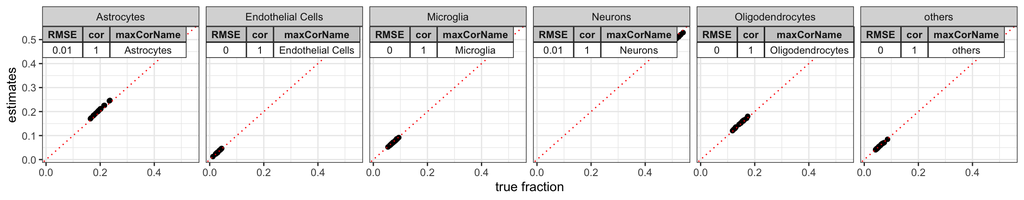

```r
deconv_performance_plot(truth_frac = t(sim.data$props),estimated_frac = t(toy_example_res@Post.ini.ct@theta))
```

We also provide a sample code demonstrating how `simdata` is created.

```r
library(Biobase)
library(BisqueRNA)
cell.types <- c("Neurons", "Astrocytes", "Oligodendrocytes", "Microglia", "Endothelial Cells","others")
avg.props <- c(.5, .2, .15, .07, .03,.05)
sim.data <- SimulateData(n.ind=20, n.genes=1000, n.cells=500, cell.types=cell.types, avg.props=avg.props)
```

#### 2. Cell state specification

In real practice, constructing a reference from single-cell data is more complex, and one cell type may not be represented by a single profile. Ideally, if finer subclustering information is available, it can directly serve as cell state labels. However, when such information is missing, we provide a `get_subcluster()` function to obtain detailed cell state information within each cell type. This function supports two types of subclustering methods: scran and SCISSORS.

**scran**  
This method implements the `quickCluster()` function from [scran](https://bioconductor.riken.jp/packages/3.8/bioc/html/scran.html) package for fast identification of subclustering information. It includes a `min.subcluster.size` hyperparameter to specify the minimum size of each subcluster.

```r
if(!requireNamespace("scran", quietly = TRUE)){
  BiocManager::install("scran")
}
library(scran)

cell_state_lables_scran = get_subcluster(scExpr = scExpr,cell_type_labels = cell_type_labels,subcluster_method = 'scran',min.subcluster.size = 200)
```

```r
table(cell_state_lables_scran)
```

```
#> cell_state_lables_scran
#>        Astrocytes_1        Astrocytes_2        Astrocytes_3        Astrocytes_4
#>                 289                 370                 275                 234
#>        Astrocytes_5        Astrocytes_6 Endothelial Cells_1         Microglia_1
#>                 374                 416                 306                 266
#>         Microglia_2           Neurons_1           Neurons_2           Neurons_3
#>                 461                 585                 688                 500
#>           Neurons_4           Neurons_5           Neurons_6           Neurons_7
#>                 488                 431                 697                 496
#>           Neurons_8           Neurons_9  Oligodendrocytes_1  Oligodendrocytes_2
#>                 615                 488                 261                 218
#>  Oligodendrocytes_3  Oligodendrocytes_4  Oligodendrocytes_5  Oligodendrocytes_6
#>                 259                 209                 207                 291
#>            others_1            others_2
#>                 340                 236
```

**SCISSORS**  
This method implements the SCISSORS method for sub-clusters identification. It contains a `SilhouetteScores.cutoff` hyperparamter to determine which cell types to be re-culstered.

```r
if(!requireNamespace("SCISSORS", quietly = TRUE)){
  remotes::install_github("jr-leary7/SCISSORS")
}
library(SCISSORS)
cell_state_lables_SCISSORS = get_subcluster(scExpr = scExpr,cell_type_labels = cell_type_labels,subcluster_method = 'SCISSORS',SilhouetteScores.cutoff = 0.7)
```

```r
table(cell_state_lables_SCISSORS)
```

```
#> cell_state_lables_SCISSORS
#>        Astrocytes Endothelial Cells         Microglia           Neurons
#>              1958               306               727              4988
#>  Oligodendrocytes            others
#>              1445               576
```

Note that for this example data, using the current `SilhouetteScores.cutoff`, we received the message: “No cell types need to be reclustered under the given SilhouetteScores.cutoff; original cell type labels will be returned.” This indicates that the cell types already demonstrate good internal consistency and are distinct from each other, thus no further subclustering is needed.

The identified cell state labels can be directly pass to `refPrepare()` function:

```r
refPhi_obj1 = refPrepare(sc_Expr = scExpr, cell.type.labels = cell_type_labels, cell.state.labels = cell_state_lables_scran)

refPhi_obj2 = refPrepare(sc_Expr = scExpr, cell.type.labels = cell_type_labels, cell.state.labels = cell_state_lables_SCISSORS)
```

In addition to the subclustering methods mentioned above, uses can also assign cell state labels based on their source of origin (using patient identifiers), when other subclustering methods are computationally intensive. This method is useful for cell types exhibiting clear intra-sample heterogeneity, such as malignant cells.

```r
# for example, recluster Neurons based on their sampleID
cell_state_lables_manual = cell_type_labels
Neurons_id = which(pData(sc.eset)$cellType == 'Neurons')
cell_state_lables_manual[Neurons_id] = paste0('Neurons_',pData(sc.eset)$SubjectName[Neurons_id])
table(cell_state_lables_manual)
```

```
#> cell_state_lables_manual
#>        Astrocytes Endothelial Cells         Microglia         Neurons_1
#>              1958               306               727               270
#>        Neurons_10        Neurons_11        Neurons_12        Neurons_13
#>               255               265               249               258
#>        Neurons_14        Neurons_15        Neurons_16        Neurons_17
#>               232               262               223               244
#>        Neurons_18        Neurons_19         Neurons_2        Neurons_20
#>               266               242               249               245
#>         Neurons_3         Neurons_4         Neurons_5         Neurons_6
#>               251               227               245               250
#>         Neurons_7         Neurons_8         Neurons_9  Oligodendrocytes
#>               250               241               264              1445
#>            others
#>               576
```

#### 3. Reference evaluation pipeline

We recognize that cell state specification is an unsupervised problem and there is no definitive answer for the hyperparameter choices. Therefore, we have provided a [reference evaluation pipeline](https://github.com/humengying0907/InstaPrismSourceCode) to facilitate deconvolution performance evaluation and guide hyperparameter choices during reference construction.

## Import a BayesPrism object for deconvolution

For users familiar with the BayesPrism working framework, InstaPrism offers a convenient way that directly accepts a `Prism` object derived from `BayesPrism::new.prism()` as input for fast deconvolution. Consider the following example from BayesPrism [tutorial](https://github.com/Danko-Lab/BayesPrism/blob/main/tutorial_deconvolution.pdf). The `extdata` folder associated can be downloaded from [zenodo](https://zenodo.org/record/7730658) repository.

#### 1. Built a `Prism` object following the BayesPrism tutorial

```r
library(BayesPrism)
# the example data is downloaded from: https://github.com/Danko-Lab/BayesPrism/tree/main/tutorial.dat
load('extdata/tutorial_example2/tutorial.gbm.rdata')
sc.stat <- plot.scRNA.outlier(
  input=sc.dat, #make sure the colnames are gene symbol or ENSMEBL ID
  cell.type.labels=cell.type.labels,
  species="hs", #currently only human(hs) and mouse(mm) annotations are supported
  return.raw=TRUE #return the data used for plotting.
  #pdf.prefix="gbm.sc.stat" specify pdf.prefix if need to output to pdf
)
bk.stat <- plot.bulk.outlier(
  bulk.input=bk.dat,#make sure the colnames are gene symbol or ENSMEBL ID
    sc.input=sc.dat, #make sure the colnames are gene symbol or ENSMEBL ID
  cell.type.labels=cell.type.labels,
  species="hs", #currently only human(hs) and mouse(mm) annotations are supported
  return.raw=TRUE
  #pdf.prefix="gbm.bk.stat" specify pdf.prefix if need to output to pdf
)
# Filter outlier genes from scRNA-seq data
sc.dat.filtered <- cleanup.genes (input=sc.dat,
                                  input.type="count.matrix",
                                    species="hs",
                                    gene.group=c( "Rb","Mrp","other_Rb","chrM","MALAT1","chrX","chrY") ,
                                    exp.cells=5)
# Subset protein coding genes
sc.dat.filtered.pc <-  select.gene.type (sc.dat.filtered,
                                        gene.type = "protein_coding")
# construct a prism object
myPrism <- new.prism(
  reference=sc.dat.filtered.pc,
  mixture=bk.dat,
  input.type="count.matrix",
  cell.type.labels = cell.type.labels,
  cell.state.labels = cell.state.labels,
  key="tumor",
  outlier.cut=0.01,
  outlier.fraction=0.1
)
# run BayesPrism
start.time = Sys.time()
bp.res <- run.prism(prism = myPrism, n.cores=16,update.gibbs=T) # set update.gibbs = T, the default option
end.time=Sys.time()
bp_running_time = difftime(end.time, start.time,units = 'mins') %>% as.numeric()
save(bp.res,bp_running_time,file = 'extdata/tutorial_example2/bp.res.RData')
```

Please note that running the above code took over **6 hours** on our system (using 16 cores). Users may bypass the BayesPrism running process by directly loading our pre-processed results.

```r
load('extdata/tutorial_example2/bp.res.RData')
```

With the default setting of BayesPrism (`update.gibbs = TRUE`), the `BayesPrism::run.prism()` function will performs two rounds of deconvolution: the first using an scRNA-based reference and the second with an updated reference. The estimated cell-type fractions are stored in `bp.res@posterior.initial.cellType@theta` and `bp.res@posterior.theta_f@theta` respectively.

#### 2. Import the `Prism` object to InstaPrism

The `InstaPrism()` function can directly accept a `Prism` object for deconvolution.

```r
InstaPrism.res.initial = InstaPrism(input_type = 'prism',prismObj = myPrism,n.core = 16)
```

Note that `InstaPrism()` function only returns the posterior estimates using scRNA-based reference. The results will correspond to `bp.res@posterior.initial.cellType` returned by BayesPrism:

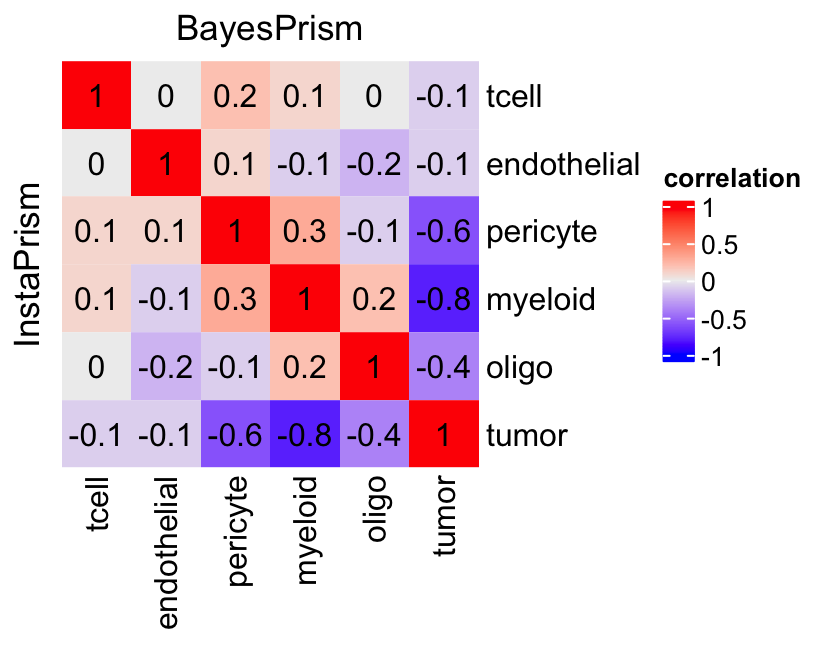

```r
# compare cell type fraction estimates between two methods
ct.corr=cor(t(InstaPrism.res.initial@Post.ini.ct@theta),bp.res@posterior.initial.cellType@theta) %>% round(1)

ComplexHeatmap::Heatmap(ct.corr,show_row_dend = F,show_column_dend = F,column_title = 'BayesPrism',row_title = 'InstaPrism',name='correlation', cell_fun = function(j, i, x, y, w, h, col) {grid::grid.text(ct.corr[i, j], x, y)})
```

The cell-type specific expression are also nearly identical:

```r
# tumor specific expression from InstaPrism
Z_tumor_ct_initial_InstaPrism = reconstruct_Z_ct_initial(InstaPrism_obj = InstaPrism.res.initial,cell.type.of.interest = 'tumor')
```

```r
# tumor specific expression from BayesPrism
Z_tumor_ct_initial_bp = bp.res@posterior.initial.cellType@Z[,,'tumor']

# compare tumor specific expression from two methods
all.equal(t(Z_tumor_ct_initial_InstaPrism),Z_tumor_ct_initial_bp)
```

```
#> [1] "Mean relative difference: 0.003338094"
```

#### 3. Get updated posterior with InstaPrism

InstaPrism incorporates the capability of reference updates with the `InstaPrism_update()` function, matching the `bp.res@posterior.theta_f` returned by BayesPrism.

```r
updated_obj = InstaPrism_update(InstaPrism.res.initial,
                                bulk_Expr = t(bp.res@prism@mixture),
                                key = 'tumor',
                                n.core = 16)
save(InstaPrism.res.initial,updated_obj,file = 'extdata/tutorial_example2/InstaPrism_res.RData')
```

The updated posterior estimates of cell type fractions are still nearly identical betweent two methods

```r
ct.corr.updated=cor(t(updated_obj@theta),bp.res@posterior.theta_f@theta)
diag(ct.corr.updated)
```

```
#>       tumor     myeloid    pericyte endothelial       tcell       oligo
#>   0.9999830   0.9999933   0.9999700   0.9999358   0.9960990   0.9999462
```

InstaPrism also supports deconvolution of gene expression using the updated reference, a feature not available with BayesPrism:

```r
Z_updated = get_Z_array(updated_obj) # the 3d expression array (sample by gene by cell type)
Z_tumor_ct_updated_InstaPrism = reconstruct_Z_ct_updated(InstaPrism_updated_obj = updated_obj,cell.type.of.interest = 'tumor') # get the tumor specific expression only
```

## Additional notes on InstaPrism parameters

So far we have demonstrated the primary usage of **InstaPrism**, mostly with the default parameters. In real practice, some of the default parameters can be tailored to meet the users’ specific requirements.

- **n.iter**: number of iterations in InstaPrism algorithm.  
  `n.iter` is an important parameter for InstaPrism algorithm. InstaPrism updates the fraction estimates over iterations and `n.iter` determines how many iterations are performed. Under default setting, this value is set to *max(100, number of cell.states $\times$ 2)*. However, users can set it to larger values to improve convergence. Specifically, we included two additional parameters that help to verify the convergence status: *verbose* and *convergence.plot*.
- **verbose**: a logical variable to determine whether to display convergence status of the model.  
  By setting `verbose = T`, `InstaPrsim()` will print the convergence status summary for both cell.states and cell.types.  
  Specifically, the absolute difference in fraction estimates between the last two iterations is utilized as an indicator of convergence (abs_diff), with smaller values indicating convergence and higher confidence of the deconvolution results. Using `example3.RData` as a demonstration, by setting `verbose = T`, we get a summarized table showing the minimum, median and maximum abs_diff for all cell.states/types across the samples. Usually we consider abs_diff < 0.01 as convergence.

```r
load('extdata/tutorial_example3/example3.RData')
ref = refPrepare(scExpr_train,cell.type.labels,cell.state.labels)
InstaPrism.res = InstaPrism(bulk_Expr = simulated_bulk,refPhi_cs = ref,
                            n.iter = 100,n.core = 8,verbose = T)
```

```
#> deconvolution with scRNA reference phi
#>
#>
#>  ********************** convergence status summary **********************
#>  instructions:
#>  the absolute difference in fraction estimates between the last two iterations is utilized as an indicator of convergence,
#>  with smaller values indicating convergence (usually consider abs_diff < 0.01 as convergence),
#>  below is a summarized convergence status for cell.states/cell.types across all the samples
#>
#>  *************** convergence status summary for cell states ***************
#>     cell.state          min       median          max
#> 1       B cell 6.548224e-14 2.049959e-06 1.336521e-05
#> 2    Dendritic 1.236121e-07 4.978702e-06 2.268643e-05
#> 3  Endothelial 1.397934e-07 8.913133e-06 4.773330e-05
#> 4   Fibroblast 1.290157e-08 1.626092e-05 6.754442e-05
#> 5        HNSCC 1.338229e-07 2.427949e-05 1.276351e-04
#> 6      HNSCC10 8.074635e-09 1.607009e-06 1.150884e-05
#> 7      HNSCC12 2.130364e-09 5.288825e-07 2.878105e-05
#> 8      HNSCC13 5.644367e-07 2.299020e-05 8.868269e-05
#> 9      HNSCC16 9.381640e-08 2.989531e-05 2.218067e-04
#> 10     HNSCC17 1.416643e-07 2.712452e-05 3.316170e-04
#> 11     HNSCC18 5.690913e-10 2.998442e-07 6.261930e-05
#> 12     HNSCC20 6.454522e-07 1.000400e-05 1.445522e-04
#> 13     HNSCC22 4.361545e-08 2.705316e-05 4.100740e-04
#> 14     HNSCC24 3.651882e-09 1.648889e-06 2.723484e-05
#> 15     HNSCC25 1.535983e-08 2.388116e-05 2.365775e-04
#> 16     HNSCC26 7.301117e-08 2.099686e-05 7.982412e-05
#> 17     HNSCC28 3.354352e-08 3.046936e-05 2.743575e-04
#> 18      HNSCC5 2.476371e-08 6.240633e-06 1.485379e-04
#> 19      HNSCC6 2.101954e-07 1.462844e-05 6.878328e-05
#> 20      HNSCC7 1.195424e-09 3.922635e-06 3.202854e-05
#> 21      HNSCC8 2.320469e-13 3.825355e-07 6.607370e-06
#> 22  Macrophage 1.571476e-07 3.985548e-06 1.401805e-05
#> 23        Mast 1.125458e-10 1.744398e-07 2.986784e-06
#> 24      T cell 5.131018e-09 1.061194e-05 4.186426e-05
#> 25     myocyte 4.036122e-10 2.153322e-07 1.785253e-06
#>
#>  *************** convergence status summary for cell types ***************
#>     cell.type          min       median          max
#> 1      B cell 6.548224e-14 2.049959e-06 1.336521e-05
#> 2   Dendritic 1.236121e-07 4.978702e-06 2.268643e-05
#> 3 Endothelial 1.397934e-07 8.913133e-06 4.773330e-05
#> 4  Fibroblast 1.290157e-08 1.626092e-05 6.754442e-05
#> 5  Macrophage 1.571476e-07 3.985548e-06 1.401805e-05
#> 6        Mast 1.125458e-10 1.744398e-07 2.986784e-06
#> 7      T cell 5.131018e-09 1.061194e-05 4.186426e-05
#> 8   malignant 1.566281e-05 3.896177e-04 9.760599e-04
#> 9     myocyte 4.036122e-10 2.153322e-07 1.785253e-06
#>
#>  ******************* end of convergence status summary ********************
#>
#> scaler calculation
```

- **convergence.plot**: a logical variable determining whether to visualize convergence status for cell types.  
  Again, using `example3.RData` as a demonstration, first let’s consider the scenario when`n.iter` is set too low. According to the convergence plot, fraction estimates for malignant cells did not converge. This means that we should set higher value of `n.iter`.

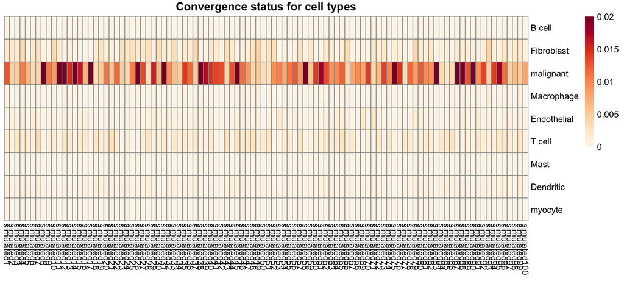

```r
InstaPrism.res = InstaPrism(bulk_Expr = simulated_bulk,refPhi_cs = ref,
                            n.iter = 20,n.core = 8,verbose = T,convergence.plot=T,max_n_per_plot = 100)
```

Now, let’s try using a higher value of `n.iter`. This time we get fraction estimation for all the cell types converge (with all the abs_diff less than 0.01).

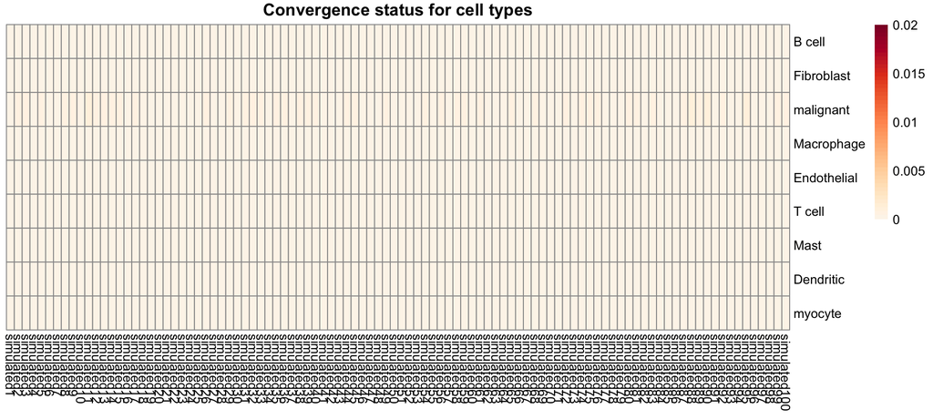

```r
InstaPrism.res = InstaPrism(bulk_Expr = simulated_bulk,refPhi_cs = ref,
                            n.iter = 100,n.core = 8,verbose = T,convergence.plot=T,max_n_per_plot = 100)
```

- **n.core**: number of cores to use for parallel programming. We recommend setting this parameter to higher value when multiple cores are available. InstaPrism functions that support parallel programming include: `InstaPrism()`, `InstaPrism_update()`, `reconstruct_Z_ct_initial()`, `reconstruct_Z_ct_updated()` and `get_Z_array()`.

## Previous tutorial

Our previous tutorial (associated with v0.1.5), which provides a more detailed comparison between InstaPrism and BayesPrism, can be accessed [here](https://humengying0907.github.io/InstaPrism_tutorial_v0.1.5.html).